# Coursework Report 218353

*N* removed NAs: 6

*N* removed <18: 33

**Correct typo age:** 20

*N* total clean: 129

| Group | *N* | *M*<sub>age</sub> | % green |
| --- | --- | --- | --- |
| Control | 63 | 21.06 | 36.51 |
| Experim | 66 | 20.91 | 54.55 |

| Gender | *N* | *M*<sub>age</sub> | % green |
| --- | --- | --- | --- |
| Male | 62 | 20.79 | 40.32 |
| Female | 46 | 21.22 | 51.45 |
| Other | 21 | 21.05 | 49.21 |

**Main analysis results**

**car:**  
χ<sup>2</sup>(1) = 4.4, *p* = .036

**cleaner:**  
χ<sup>2</sup>(1) = 4.15, *p* = .042

**dishwasher:**  
χ<sup>2</sup>(1) = 2.29, *p* = .130

[interactive chart not shown]

[figure not shown]

[interactive chart not shown]

# Coursework Report 218353

Analysing Data, Spring 2020

# Methods

## Participants

Table 1. *Descriptive statistics by Gender*

[output not shown]

Table 2. *Descriptive statistics by Condition*

[output not shown]

## Design

The research aims to find out whether the activation of status motives (by telling a story) can influence the product choices that people make when choosing between a green product and a luxurious product. This is an independent group design. The participants will either be arranged into the controlled or the experimental group. Only the experimental group would be told a story before the start of the experiment. The story is around 700 words. It is about being a part of the story and graduating from college, they start searching for a job, and finally divide to go work in a large company because it offers the best chance of promotion. This story describes the first day in work and focuses on the luxurious details of the workplace such as upscale lobby and nice furniture. Readers know they will have an opportunity of a desirable promotion at the end. This story has been used successfully to induce status motives response in previous research (Griskevicius, Tybur et al., 2009). During the experiment, participants of both conditions are asked to consider in purchasing of three types of product; a car, a household cleaner, and a dishwasher. They are also told that these products are chosen because the products are available in pro-environmental and a conventional form. Each type of product is environmentally friendly in different ways (low CO2 emissions, nontoxic, and water efficient, respectively). For each choice, the products are equal in price and are manufactured by the same company. The data which we have collected is the participants age and gender. The type of product they have chosen (e.g. green car or luxurious car). Of which only the age is a numeric factor while other data are factors. For gender, there are three factor levels consists of male, female and others. Condition consists of two, control and experimental. Product has three levels including car, cleaner and dishwasher. And finally, category consists of two levels luxury and green. By comparing each product type paired with a category to the condition of the experiment (controlled or experimental). The frequency of both groups is recorded and compared to show whether the status motive have influenced the participant’s decision. The hypothesis of the experiment is there will be no connection between status motives and the category of product chosen. A chi-square test will be conducted.

# Results

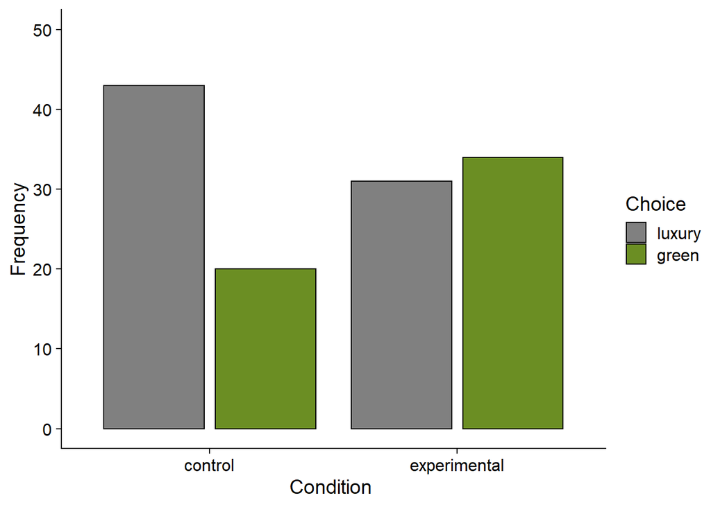

Figure 1. The frequency of choices of cars by condition

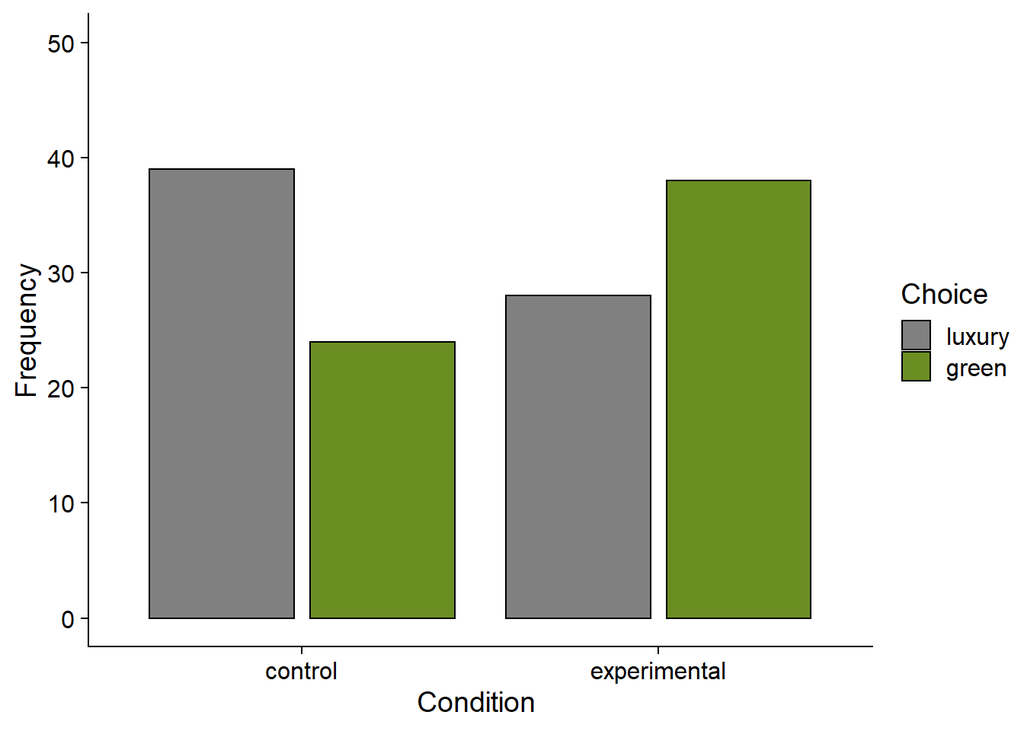

Figure 2. The frequency of choices of cleaners by condition

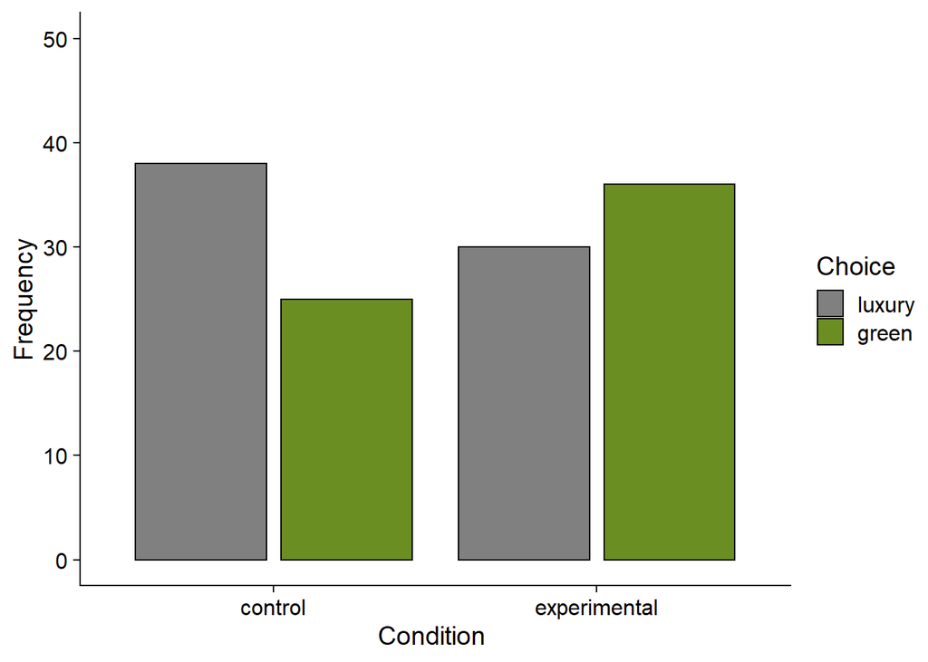

Figure 3. The frequency of choices of dishwasher by condition

Table 3. *Frequency table of car choices*

|  | control | experimental |
| --- | --- | --- |
| luxury | 43 | 31 |
| green | 20 | 34 |

Table 4. *Frequency table of dishwasher choices*

|  | control | experimental |
| --- | --- | --- |
| luxury | 38 | 30 |
| green | 25 | 36 |

Table 5. *Frequency table of cleaner choices*

|  | control | experimental |
| --- | --- | --- |
| luxury | 39 | 28 |
| green | 24 | 38 |